# Homocedasticity

Guillem

3 March 2020

Sea $X$ una población normal con $\sigma=1.8$.

$$\left\{
\begin{array}{ll}
H_0: & \sigma_1^2 = \sigma_1^2 = \cdots = \sigma_k^2 \\
H_1: & \exists i, j : \sigma_i^2 \neq \sigma_j^2
\end{array}
\right.$$
## EMPEZAMOS HACIENDO UN EDA

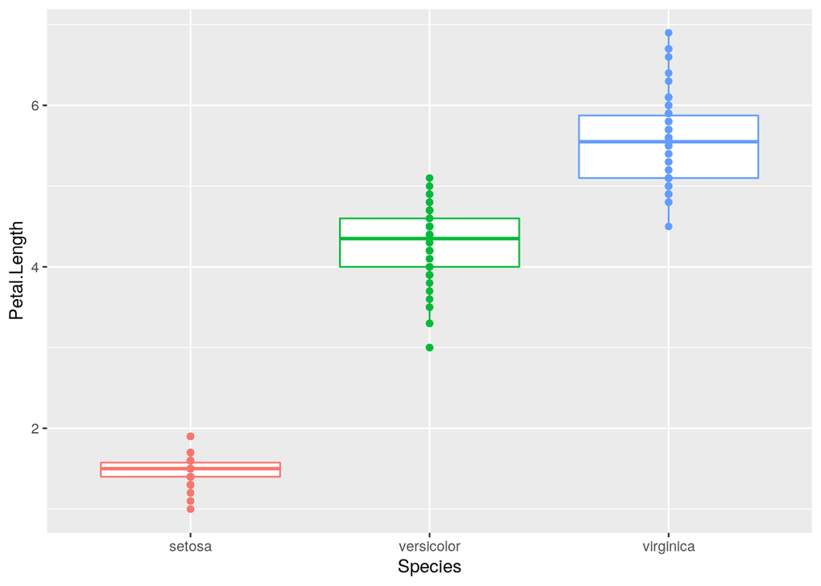

```r
iris %>%
  ggplot(aes(x = Species, y = Petal.Length, color = Species)) +
  geom_boxplot()+
  geom_point()+
  theme(legend.position = "none")
```

```r
aggregate(Petal.Length ~ Species, data = iris, FUN = var)
```

```
##      Species Petal.Length
## 1     setosa   0,03015918
## 2 versicolor   0,22081633
## 3  virginica   0,30458776
```

### Test F de la razón de varianzas.

Contrasta la hipótesis nula de que las varianzas de dos poblaciones son la misma. Es un contraste muy potente porque detecta diferencias muy sutiles pero muy sensible a violaciones de la condición de normalidad de la población

Es útil si se sabe que las muestras son normales y quieres contrastar dos poblaciones únicamente.

```r
iris2 <- filter(.data = iris, Species %in% c("versicolor", "virginica"))
```

$$F = \frac{\sigma_2^2 \tilde{S}_1}{\sigma_1^2 \tilde{S}_2} \sim F_{n_1 -1, n_2 -1}$$

```r
var.test(x = iris[iris$Species == "versicolor",]$Petal.Length, y = iris[iris$Species == "virginica",]$Petal.Length)
```

```
##
##  F test to compare two variances
##
## data:  iris[iris$Species == "versicolor", ]$Petal.Length and iris[iris$Species == "virginica", ]$Petal.Length
## F = 0,72497, num df = 49, denom df = 49, p-value = 0,2637
## alternative hypothesis: true ratio of variances is not equal to 1
## 95 percent confidence interval:
##  0,411402 1,277530
## sample estimates:
## ratio of variances
##          0,7249678
```

### Test de Levene

El test de Levene permite comparar dos o más poblaciones y permite elegir distintos estadísticos de centralidad.

```r
library(lawstat)
levene.test(iris$Petal.Length, iris$Species, location = "median")
```

```
##
##  Modified robust Brown-Forsythe Levene-type test based on the absolute
##  deviations from the median
##
## data:  iris$Petal.Length
## Test Statistic = 19,48, p-value = 3,129e-08
```

```r
levene.test(iris2$Petal.Length, iris2$Species, location = "median")
```

```
##
##  Modified robust Brown-Forsythe Levene-type test based on the absolute
##  deviations from the median
##
## data:  iris2$Petal.Length
## Test Statistic = 1,0674, p-value = 0,3041
```

Mientras que las 3 poblaciones no poseen la misma varianza las poblaciones versicolor y viginica no muestran evidencias suficientes para rechazar que no tenga varianzas iguales.

### Test de Bartlett

```r
bartlett.test(Petal.Length ~ Species, data = iris)
```

```
##
##  Bartlett test of homogeneity of variances
##
## data:  Petal.Length by Species
## Bartlett's K-squared = 55,423, df = 2, p-value = 9,229e-13
```

```r
bartlett.test(Petal.Length ~ Species, data = iris2)
```

```
##
##  Bartlett test of homogeneity of variances
##
## data:  Petal.Length by Species
## Bartlett's K-squared = 1,249, df = 1, p-value = 0,2637
```

El test de Bartlett nos dice los mismo que el de Levene, mientras que las 3 poblaciones no poseen la misma varianza las poblaciones versicolor y viginica no muestran evidencias suficientes para rechazar que no tenga varianzas iguales.

### Test de Brown-Forsyth

El paquete HH no se puede descargar en Linux por problemas de dependencia, no obstante el Test de Brown-Forsyth es igual al test de Levene cuando se utiliza una mediana como medidad de centralidad.

### Test de Fligner-Killen

Es un test no paramétrico que utiliza la mediana para la comparación de varianzas por lo que es recomendable cuando no se cumple la condición de normalidad

```r
fligner.test(Petal.Length ~ Species, data = iris)
```

```
##
##  Fligner-Killeen test of homogeneity of variances
##
## data:  Petal.Length by Species
## Fligner-Killeen:med chi-squared = 34,708, df = 2, p-value = 2,906e-08
```